# Design Overview

This file shows the wt-v-ko comparison for Haunt.

Cuff overview:

```
## CuffSet instance with:
##   2 samples
##   26754 genes
##   77524 isoforms
##   0 TSS
##   23066 CDS
##   0 promoters
##   0 splicing
##   19954 relCDS
```

# QC

## Dispersion

Dispersion plot for genes in cuff: (Overdispersion can lead to innacurate quants)

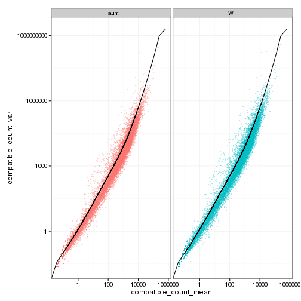

## Cross-replicate variability (fpkmSCVplot)

Differences in CV 2 can result in lower numbers of differentially expressed genes due to a higher degree of variability between replicate fpkm estimates.

Genes:

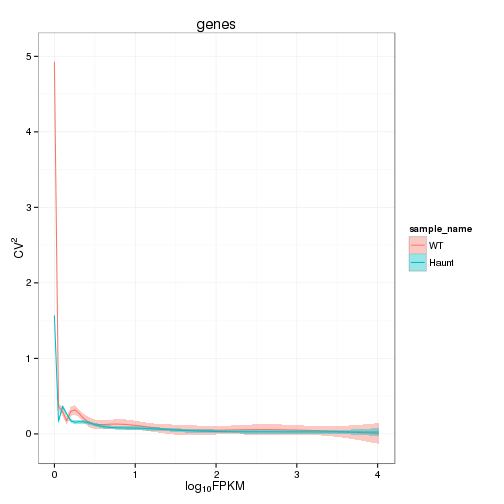

Isoforms:

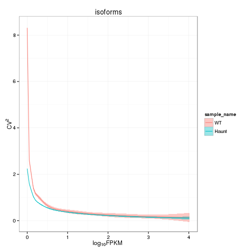

## MvA plot

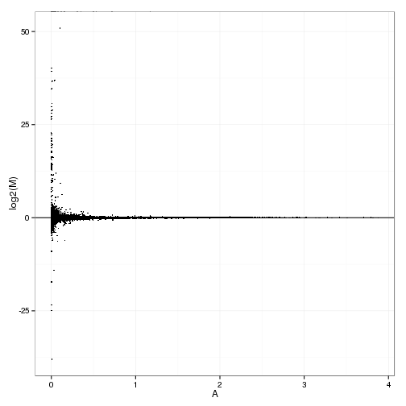

### MvA plot counts

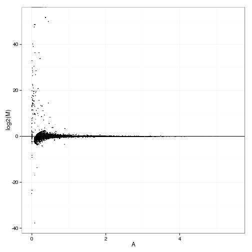

## Scatterplot matrix

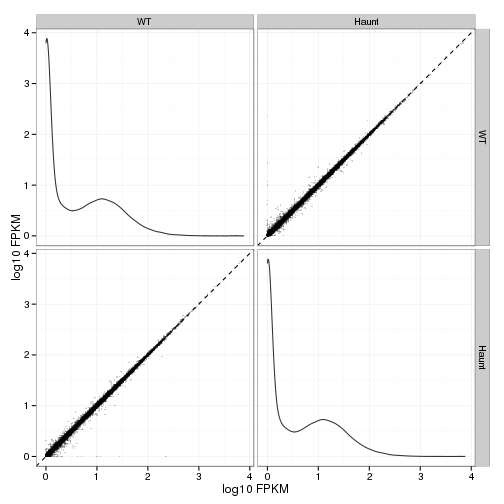

## Distributions

### Boxplots

Boxplot (genes)

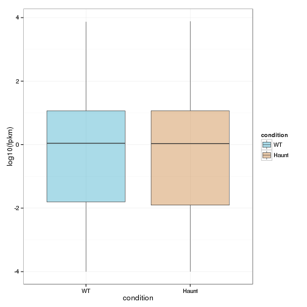

Boxplot (genes, replicates)

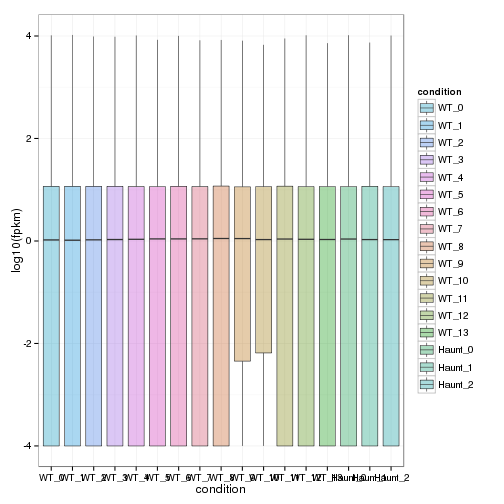

Boxplot (isoforms)

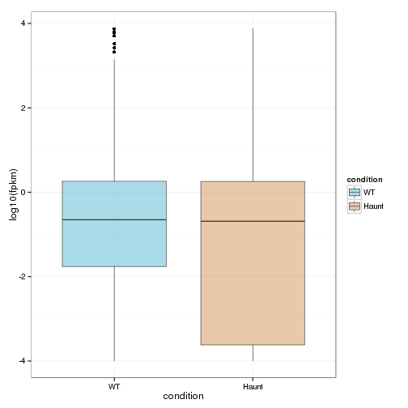

Boxplot (isoforms, replicates)

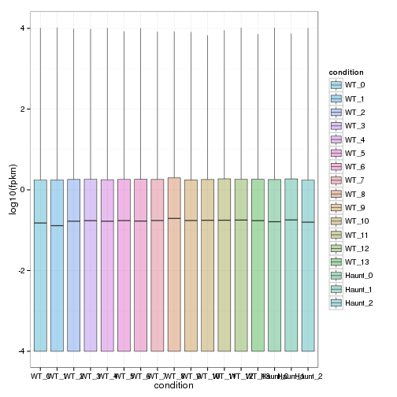

### Density

Density (genes)

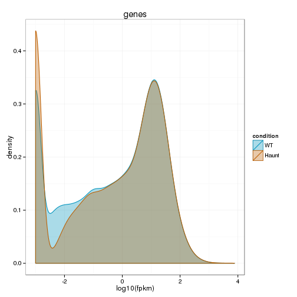

Density (genes, replicates)

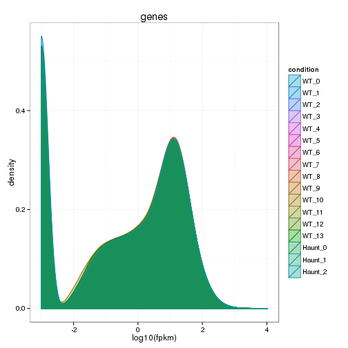

## Clustering

### Replicate Clusters

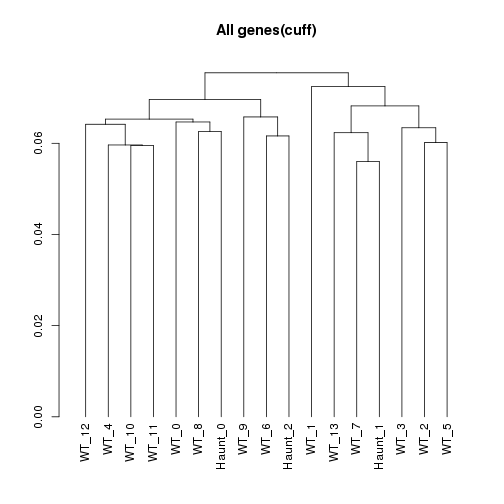

### PCA (genes)

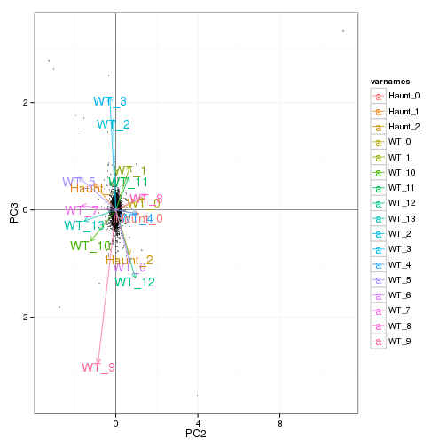

### MDS (genes)

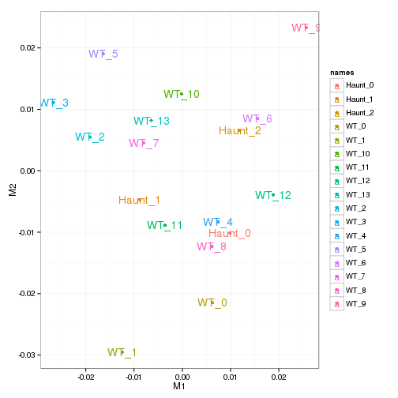

# KO assessment

## Endogenous lncRNA expression

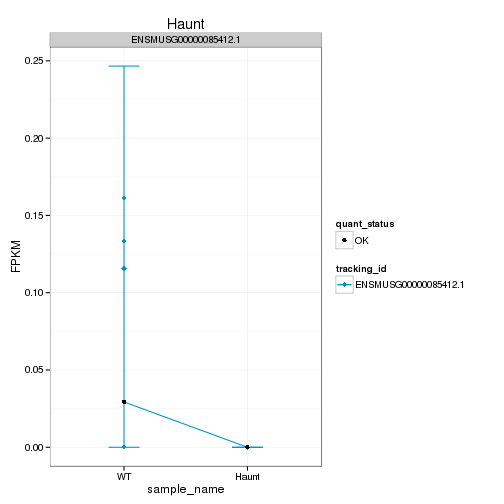

Endogenous expression of Haunt isoforms:

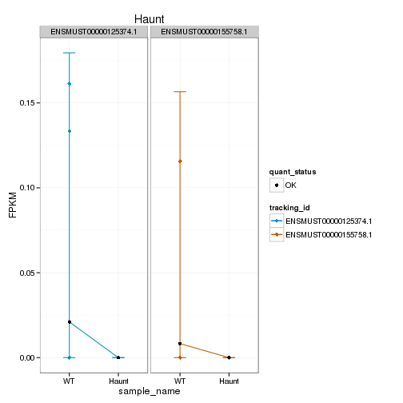

Barplot of gene expression:

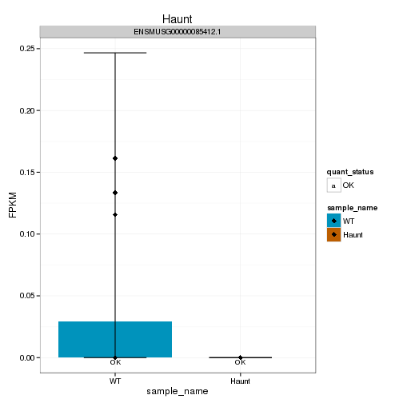

Barplot of isoform expression:

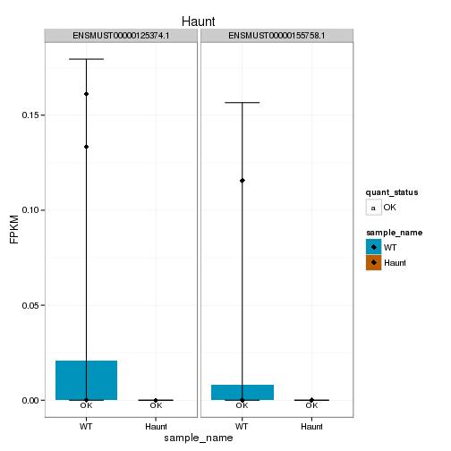

## LacZ expression

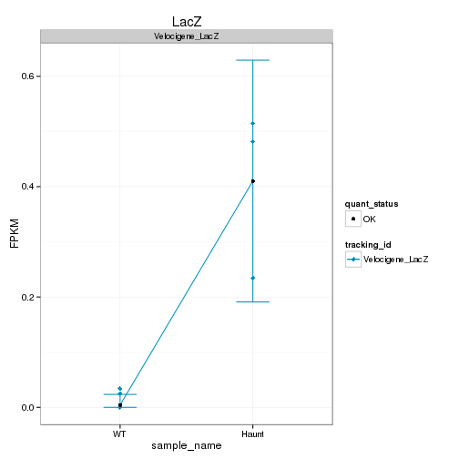

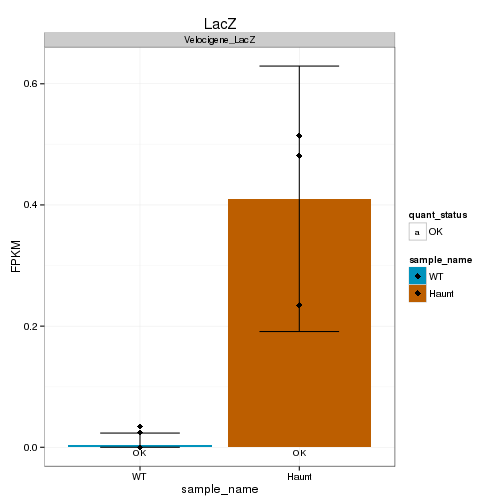

## Digital Genotyping (LacZ vs Endogenous lncRNA and Sex)

Expression plot (endogenous linc, lacZ, Y-expressed gene):

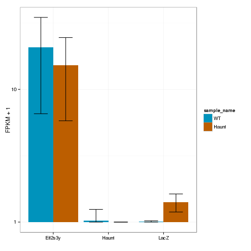

Expression heatmap:

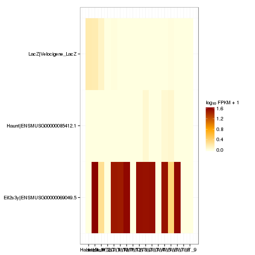

[output not shown]

# Differential Analysis

## Differential Genes

There are 37 significantly differentially expressed genes. They are:

|  | geneAnnot$gene_short_name |
| --- | --- |
| 1 | Hspa8 |
| 2 | Pttg1 |
| 3 | Adi1 |
| 4 | Serpina3n |
| 5 | Fos |
| 6 | Arc |
| 7 | Nr4a1 |
| 8 | Glo1 |
| 9 | Xdh |
| 10 | Nr4a3 |
| 11 | Hddc3 |
| 12 | Cryab |
| 13 | Arhgap27 |
| 14 | Fam214a |
| 15 | Filip1 |
| 16 | Klf10 |
| 17 | Egr2 |
| 18 | Txnip |
| 19 | Egr1 |
| 20 | Akap12 |
| 21 | Atp5l |
| 22 | Gm9493 |
| 23 | Acp1 |
| 24 | Npas4 |
| 25 | Scn4b |
| 26 | Hbb-bs |
| 27 | Junb |
| 28 | Kdm5d |
| 29 | Tpm3-rs7 |
| 30 | Rpl30 |
| 31 | Rpl34 |
| 32 | Ddx3y |
| 33 | Egr4 |
| 34 | Gm7292 |
| 35 | AA465934 |
| 36 | Rpl41 |
| 37 | Gm26825 |

### Matrix of gene significant differences between conditions

(skip for Brainmap wt-v-ko comparisons)

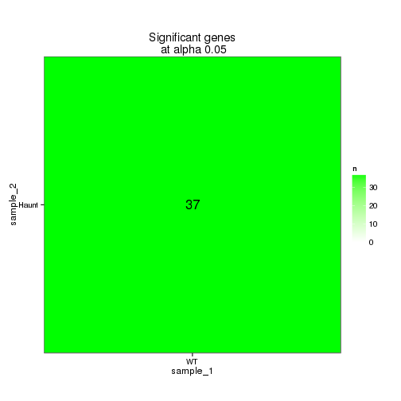

### Significant gene expression differences between conditions

Expression plot (genes):

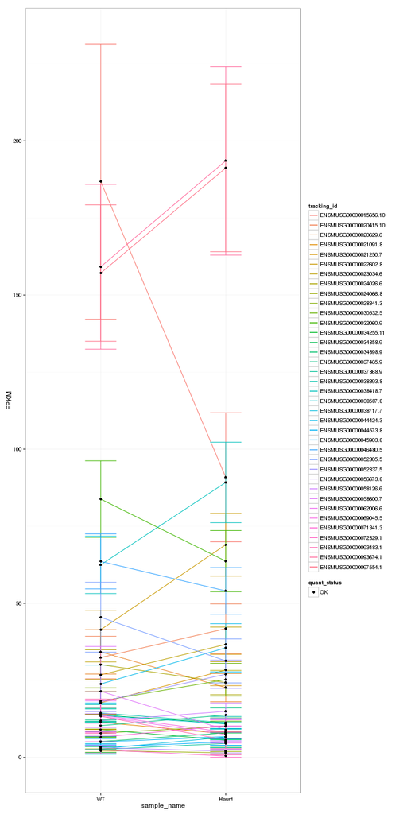

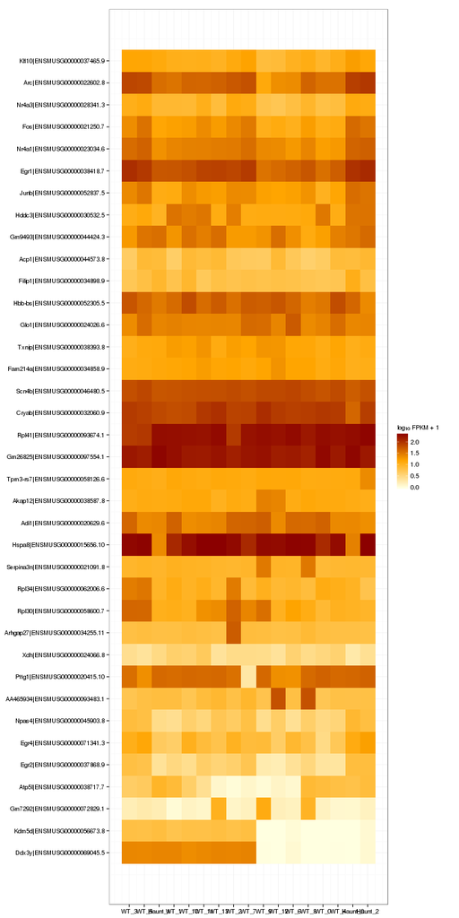

Significant genes with expression >50fpkm (any condition):

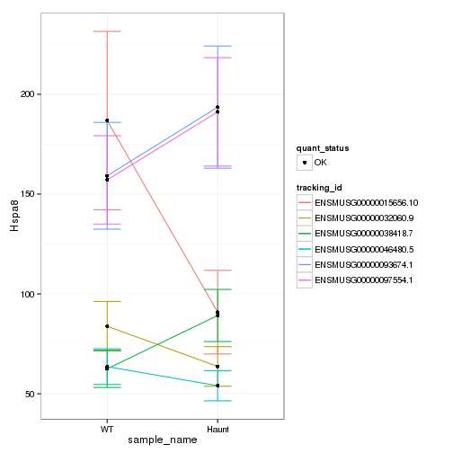

### Expression-level/significance relationship

Scatter plot of significant genes only:

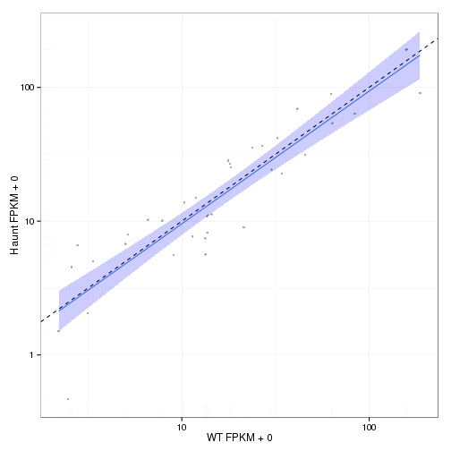

Volcano Plot

Volcano plot with significant genes only:

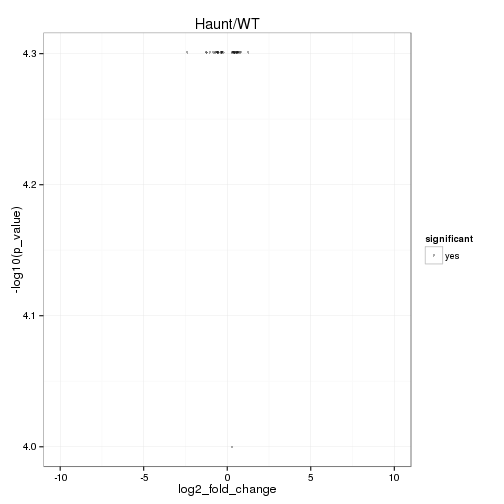

FoldChange Heatmap

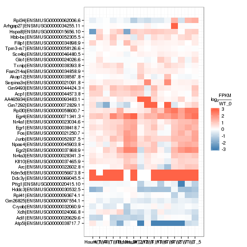